# A Course on Numerical Linear Algebra

*Instructor:* Deniz Bilman

*Textbook:* Numerical Linear Algebra, by Trefethen and Bau.

# Lecture 4 (Continued): Straightforward Applications of Singular Value Decomposition (SVD)

```julia
using LinearAlgebra
using Plots

# using Pkg
# Pkg.add(["Images", "ImageIO"])

using Images, ImageIO
```

## Low-Rank Approximation of an Image

This is not the best way to compress an image, but it provides a somewhat cute and straightforward application of SVD. Algorithms like JPEG rely on DCT (Discrete Cosine Transform), but the main idea is similar.

### Example 1: A Blue Note Record Cover by Reid Miles

[figure not shown]

```julia
# Load an image from a file
img = load("figs/hubbard-bn.jpg");

# Let's display the image
display(img)
```

We should convert this image object into a matrix. We will also convert it to grayscale so that each pixel in the image corresponds to the entry of a matrix, and there is only one channel (gray) to encode.

You can do this with RGB channels if you'd like.

```julia
# We should convert the image (sadly) to a grayscale matrix.
gray_img = Gray.(img)  # Converts to grayscale if it's not already
display(gray_img) # Display the grayscale image
gray_matrix = Float64.(gray_img)  # Converts pixel values to Float64
```

```
900×900 Matrix{Float64}:
 0.890196  0.886275  0.886275  0.886275  …  0.854902  0.862745  0.870588
 0.901961  0.898039  0.894118  0.894118     0.870588  0.87451   0.882353
 0.917647  0.913725  0.913725  0.913725     0.847059  0.85098   0.854902
 0.937255  0.933333  0.929412  0.929412     0.831373  0.831373  0.835294
 0.952941  0.94902   0.945098  0.941176     0.862745  0.858824  0.858824
 0.960784  0.956863  0.952941  0.94902   …  0.882353  0.878431  0.87451
 0.968627  0.964706  0.956863  0.952941     0.886275  0.878431  0.87451
 0.968627  0.964706  0.956863  0.952941     0.898039  0.890196  0.886275
 0.945098  0.945098  0.945098  0.945098     0.870588  0.878431  0.886275
 0.94902   0.945098  0.945098  0.945098     0.862745  0.866667  0.87451
 ⋮                                       ⋱
 0.980392  0.972549  0.964706  0.952941     0.835294  0.831373  0.831373
 0.980392  0.968627  0.94902   0.937255     0.815686  0.823529  0.835294
 0.972549  0.956863  0.929412  0.905882     0.776471  0.788235  0.796078
 0.968627  0.941176  0.901961  0.87451      0.74902   0.745098  0.737255
 0.960784  0.933333  0.886275  0.85098   …  0.745098  0.721569  0.701961
 0.956863  0.945098  0.909804  0.882353     0.764706  0.72549   0.682353
 0.933333  0.913725  0.886275  0.862745     0.784314  0.772549  0.760784
 0.890196  0.87451   0.85098   0.835294     0.905882  0.917647  0.929412
 0.854902  0.843137  0.827451  0.819608     0.952941  0.964706  0.972549
```

#### Supplementary Code: Color Channels

If you'd like to keep track of the color channels, do the following.

```julia
# Extract RGB channels
red_channel = Float64.(channelview(img)[1, :, :])
green_channel = Float64.(channelview(img)[2, :, :])
blue_channel = Float64.(channelview(img)[3, :, :])

# Display the red channel as a heatmap
heatmap(red_channel, color=:reds, aspect_ratio=:equal, title="Red Channel", yflip=true)
```

[figure not shown]

```julia
# Display the blue channel as a heatmap
heatmap(red_channel, color=:blues, aspect_ratio=:equal, title="Blue Channel", yflip=true)
```

[figure not shown]

#### Back to the example & SVD

```julia
# Making sure the type is Float64
println(typeof(gray_matrix))
size(gray_matrix)|>display

U, Σ, V = svd(gray_matrix);

println("Size of U: ", size(U))
println("Size of Σ: ", size(Σ))
println("Size of V: ", size(V))

scatter(Σ)
```

```
(900, 900)
```

```
Matrix{Float64}
Size of U: (900, 900)
Size of Σ: (900,)
Size of V: (900, 900)
```

[figure not shown]

```julia
# Reconstruction test

norm(gray_matrix - (U * Diagonal(Σ) * V'))
```

```
3.940418380586986e-12
```

```julia
# Let's write a routine to reconstruct the image using the top k singular values
function low_rank_approximation(U, Σ, V, k)
    # U_k = U[:, 1:k]  # Top k columns of U
    # Σ_k = Diagonal(Σ[1:k])  # Top k singular values
    # V_k = V[1:k, :]  # Top k rows of Vt
    return U[:, 1:k] * Diagonal(Σ[1:k]) * (V[:, 1:k]')  # Reconstructed matrix
end
```

```
low_rank_approximation (generic function with 1 method)
```

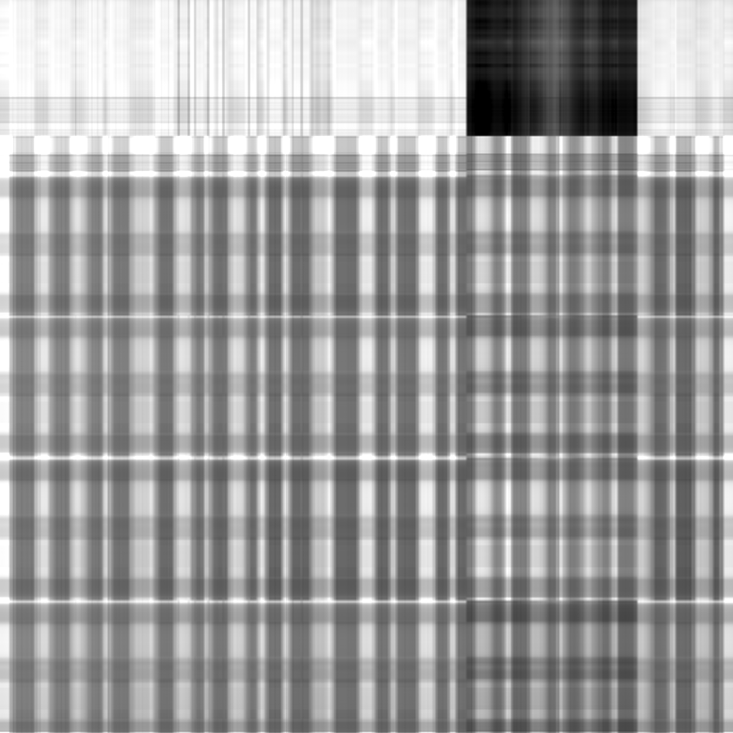

```julia
# Choose rank k for approximation
k = 2  # You can experiment with different values of k
approx_matrix = low_rank_approximation(U, Σ, V, k)
approx_img = Gray.(approx_matrix)
```

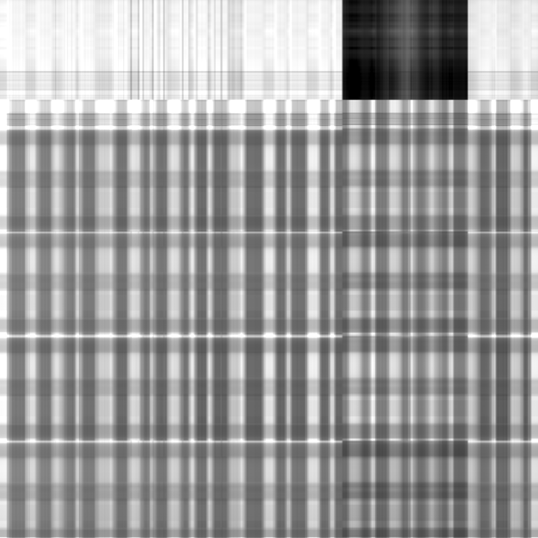

```julia
display(gray_img)
display(approx_img)
```

[figure not shown]

```julia
# Choose rank k for approximation
k = 20  # You can experiment with different values of k
approx_matrix = low_rank_approximation(U, Σ, V, k)
approx_img = Gray.(approx_matrix)
display(gray_img)
display(approx_img)
```

```julia
scatter(Σ, yaxis=:log)
```

[figure not shown]

```julia
# Choose rank k for approximation
k = 60  # You can experiment with different values of k
approx_matrix = low_rank_approximation(U, Σ, V, k)
approx_img = Gray.(approx_matrix)
display(gray_img)
display(approx_img)
```

[figure not shown]

```julia
# Choose rank k for approximation
k = 150  # You can experiment with different values of k
approx_matrix = low_rank_approximation(U, Σ, V, k)
approx_img = Gray.(approx_matrix)
display(gray_img)
display(approx_img)
```

It is an easy coding exercise to do this with the colored version of the image. Just split to RGB channesl, run SVD on them, and combine aprroximated matrices for the channels back.

### Example 2: A Portrait of Keith Jarrett

Here is a Promotional photo of Keith Jarrett in Los Angeles, August 1975, for ABC/Impulse! Records.

```julia
# Load an image from a file
img = load("figs/jarrett-portrait.jpeg");

# Let's display the image
display(img)
```

```julia
# The image is already in grayscale but let's convert to have the correct data structure
gray_img = Gray.(img)  # Converts to grayscale if it's not already
# display(gray_img) # Display the grayscale image
gray_matrix = Float64.(gray_img)  # Converts pixel values to Float64
```

```
1106×935 Matrix{Float64}:
 0.552941  0.568627  0.564706  0.552941  …  0.317647  0.294118  0.301961
 0.560784  0.556863  0.552941  0.556863     0.313725  0.301961  0.298039
 0.54902   0.537255  0.533333  0.545098     0.305882  0.294118  0.278431
 0.552941  0.54902   0.552941  0.568627     0.294118  0.278431  0.270588
 0.541176  0.537255  0.541176  0.556863     0.290196  0.278431  0.286275
 0.541176  0.533333  0.52549   0.529412  …  0.301961  0.298039  0.317647
 0.545098  0.54902   0.541176  0.541176     0.309804  0.313725  0.329412
 0.533333  0.533333  0.529412  0.537255     0.305882  0.305882  0.309804
 0.541176  0.533333  0.529412  0.556863     0.305882  0.298039  0.294118
 0.537255  0.545098  0.517647  0.521569     0.286275  0.305882  0.313725
 ⋮                                       ⋱
 0.960784  0.956863  0.960784  0.960784     1.0       1.0       1.0
 0.964706  0.960784  0.960784  0.964706     1.0       1.0       1.0
 0.968627  0.964706  0.964706  0.964706     1.0       1.0       1.0
 0.968627  0.964706  0.964706  0.960784  …  1.0       1.0       1.0
 0.968627  0.964706  0.960784  0.956863     1.0       1.0       1.0
 0.972549  0.968627  0.960784  0.960784     1.0       1.0       1.0
 0.968627  0.968627  0.964706  0.968627     1.0       1.0       1.0
 0.968627  0.968627  0.968627  0.968627     1.0       1.0       1.0
 0.968627  0.968627  0.968627  0.964706  …  1.0       1.0       1.0
```

```julia
U, Σ, V = svd(gray_matrix);

println("Size of U: ", size(U))
println("Size of Σ: ", size(Σ))
println("Size of V: ", size(V))

scatter(Σ)
```

```
Size of U: (1106, 935)
Size of Σ: (935,)
Size of V: (935, 935)
```

[figure not shown]

```julia
scatter(Σ, yaxis=:log)
```

[figure not shown]

```
935
```

```
20
```

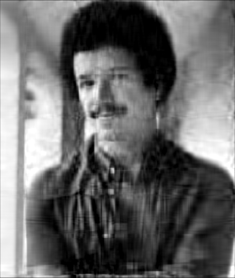

```julia
# Choose rank k for approximation
display(length(Σ))
k = 20  # You can experiment with different values of k
display(k)
approx_matrix = low_rank_approximation(U, Σ, V, k)
approx_img = Gray.(approx_matrix)
display(gray_img)
display(approx_img)
```

```
935
```

```
80
```

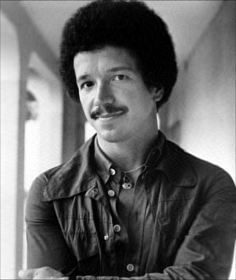

```julia
# Choose rank k for approximation
display(length(Σ))
k = 80  # You can experiment with different values of k
display(k)
approx_matrix = low_rank_approximation(U, Σ, V, k)
approx_img = Gray.(approx_matrix)
display(gray_img)
display(approx_img)
```

### Thinking & Reading Exercise

How to choose $k$ in general?

## Audio Compression

One can apply a similar idea to compress songs, although at first sight audio files are not matrices at first sight.

```julia
using WAV, DSP

# Load the audio file
signal, fs = wavread("audios/sample-song.wav")
size(signal)
```

```
(9778440, 2)
```

```julia
# Generate the time vector based on the sampling frequency
time = collect(0:length(signal)-1) / fs;

# Downsample for plotting
# factor = 100  # Downsample factor (adjust as needed)
# signal_downsampled = signal[1:factor:end, :];
# time_downsampled = time[1:factor:end];

# Smaller signal for plotting
time_small = time[50000:55000];
signal_small = signal[50000:55000,:];
size(signal_small)
```

```
(5001, 2)
```

```julia
# Plot the signal
plot(time_small, signal_small[:, 1], label="Left Channel", xlabel="Time (s)", ylabel="Amplitude", title="Waveform of Audio File")
plot!(time_small, signal_small[:, 2], label="Right Channel", xlabel="Time (s)", ylabel="Amplitude", title="Waveform of Audio File")
# display(p)
```

[figure not shown]

The idea is to create a spectogram of the song. This shows the amplitude packed in each frequency over time.

```julia
# If stereo, take one channel (for simplicity)
if size(signal, 2) == 2
    signal_ch1 = signal[:, 1]
    signal_ch2 = signal[:, 2]
end
```

```
9778440-element Vector{Float64}:
 0.0
 0.0
 0.0
 0.0
 0.0
 0.0
 0.0
 0.0
 0.0
 0.0
 ⋮
 0.0
 0.0
 0.0
 0.0
 0.0
 0.0
 0.0
 0.0
 0.0
```

```julia
# Define parameters for the STFT
window_length = 1024
hop_size = 512

# Use a rectangular window
rectangular_window = ones(window_length)

# Compute the STFT
spectrogram_ch1_matrix = stft(signal_ch1, window_length, hop_size, window=rectangular_window)
spectrogram_ch2_matrix = stft(signal_ch2, window_length, hop_size, window=rectangular_window)

# Compute frequency axis in Hz
frequencies = (0:(window_length ÷ 2)) .* (fs / window_length)

# Compute the magnitude
mag_spec_ch1 = abs.(spectrogram_ch1_matrix)
mag_spec_ch2 = abs.(spectrogram_ch2_matrix)

# Convert magnitude to dB (adding a small value to avoid log(0))
mag_spec_ch1_db = 20 .* log10.(mag_spec_ch1 .+ 1e-6)
mag_spec_ch2_db = 20 .* log10.(mag_spec_ch2 .+ 1e-6)
```

[output not shown]

```julia
ch=1
p1 = heatmap(
        1:size(mag_spec_ch1_db, 2),    # Time bins (x-axis)
        frequencies,                  # Frequency bins in Hz (y-axis)
        mag_spec_ch1_db,
        xlabel="Time (frames)",
        ylabel="Frequency (Hz)",
        title="Spectrogram (dB) - Channel $ch",
        color=:viridis,
        clims=(-80, 0)
    )
```

[figure not shown]

```julia
ch=2
p1 = heatmap(
        1:size(mag_spec_ch2_db, 2),    # Time bins (x-axis)
        frequencies,                  # Frequency bins in Hz (y-axis)
        mag_spec_ch1_db,
        xlabel="Time (frames)",
        ylabel="Frequency (Hz)",
        title="Spectrogram (dB) - Channel $ch",
        color=:viridis,
        clims=(-80, 0)
    )
```

[figure not shown]

```julia
mag_spec_ch1_db|>size
```

```
(513, 14237)
```

You see, the spectogram is a matrix $X$. A column $X_{:,j}$ denotes the amplitudes of each of the frequencies at time $t=j$. The plot you see is the amplitude values converted to decibels for better interpretability.

One can perform SVD on the spectogram (on the original amplitude spectorgram).

```julia
# Apply SVD
U1, Σ1, V1 = svd(mag_spec_ch1)
U2, Σ2, V2 = svd(mag_spec_ch2)
```

[output not shown]

[output cut: 12 more lines]

[output not shown]

```julia
# Check reconstruction

norm(mag_spec_ch1 - (U1*Diagonal(Σ1)*V1'))|>display
norm(mag_spec_ch2 - (U2*Diagonal(Σ2)*V2'))|>display
```

```
1.2478581880675971e-10
```

```
1.8788573655851484e-10
```

```julia
scatter(Σ1)
```

[figure not shown]

```julia
# Choose rank k for approximation
display(length(Σ))
k = 200  # You can experiment with different values of k
display(k)
approx_matrix_ch1 = low_rank_approximation(U1, Σ1, V1, k)
approx_matrix_ch2 = low_rank_approximation(U2, Σ2, V2, k)
```

```
935
```

```
200
```

```
513×14237 Matrix{Float64}:
 0.00283331  0.241185    20.7069     28.2846    …  0.318758     0.16976
 0.00403869  0.215964    22.394      56.3362       0.528413     0.634764
 0.00446821  0.148347    33.5927    150.54         0.329872     0.341527
 0.00538502  0.175066    48.6376    228.444        0.467405     0.397562
 0.00550176  0.201721    56.0723      9.78594      0.179187     0.208917
 0.00607168  0.0948565   45.8744     44.0422    …  0.107496     0.217965
 0.00648448  0.0905741   23.1877     28.8119       0.122        0.0290338
 0.00681259  0.124919     9.33198    39.3163       0.104432     0.0668273
 0.00737487  0.146693    14.1109     28.2205       0.0508207    0.117869
 0.00798255  0.12157     12.2272     27.112        0.0487166    0.0818487
 ⋮                                              ⋱  ⋮
 0.00123378  0.00875555   0.104764    0.23844      0.000624025  0.00064167
 0.00123578  0.00880708   0.104354    0.238665  …  0.000625061  0.000641757
 0.00123929  0.00877021   0.105429    0.237857     0.000623739  0.000641299
 0.00123492  0.00877966   0.103722    0.238421     0.000620088  0.00064096
 0.00123857  0.00878005   0.105254    0.238274     0.000621297  0.000640669
 0.00123611  0.00875183   0.104342    0.238151     0.00062167   0.000639449
 0.00122917  0.00878595   0.104174    0.237879  …  0.000621869  0.000640826
 0.00123693  0.00878088   0.104994    0.238786     0.000623753  0.00064173
 0.00124383  0.00880041   0.103948    0.236722     0.000622207  0.000640899
```

Now we have a lower rank approximation of the amplitude spectogram for the left channel and the right channel. We do not have the phase information for the spectogram --- remember, the output of the Fourier transform (FFT) is complex-valued and we took the modulus to work with amplitudes of the frequencies.

There is a well-known algorithm called *Griffin-Lim Algorith* to reconstruct the phase information from the amplitude spectogram. It is an iterative algorithm.

Once we have a good approximation of the phase information for the approximate spectograms, we can compute the inverse STFT (short-time Fourier transform) to reconstruct the signal (i.e., the song's left and right stereo channels).

**Exercise:** Do this and have a listen. Can your ear detect a lower quality? Play with the values of $k$.

## Movie Recommendation

This is an important example of the general problem of **matrix completion** (see "The Netflix Problem"). SVD plays a role in this! I will provide more details later, but basically one deals with a matrix of `users` vs. `movies` where each entry of the matrix corresponds to the rating of a user for a movie. Of course not every user has rated every movie, hence the problem of completion.

Completion of the matrix means that you can guess which movies a user would rank highly and recommend those movies to the user.

The actual algorithms at play are complicated. We will provide a straightforward and simple approach later. What we do is called *collaborative filtering*, where users' past experience is the only data taken into account in order to design a recommender. Movie date, actors, genre, production year, keywords in the plot, etc. are not taken into account.

Below is a toy rating matrix.

```julia
# Toy user-movie rating matrix (missing entries are NaN)
ratings = [5.0 4.0 NaN 1.0;
           4.0 NaN NaN 1.0;
           1.0 1.0 NaN 5.0;
           NaN 4.0 5.0 NaN]
```

## Natural Language Processing

This usually goes by the name *Latent Semantic Analysis*.

A term-document matrix (TDM) is a mathematical representation of a collection of documents using a two-dimensional matrix. The rows of the matrix represent documents, and the columns represent terms (or vice versa). The values in the cells of the matrix indicate how often a term appears in a document.

One can use this framework to extract topics from a collection of news articles, for example.

## Anomaly & Outlier Detection

This lies in the general problem of detecting low-rank structures in data. A straightforward (and maybe too simple) approach using directly SVD oprates under the assumption that anomalies (e.g., outliers or noise) manifest themselves in the small singular values of a data matrix.

```julia
using LinearAlgebra, Random, Statistics

# Generate a synthetic dataset (rows: samples, columns: features)
Random.seed!(42)
data = vcat(andn(200, 8), randn(2, 8) .+ 30)  # Add anomalies as outliers
```

[output not shown]

## Removing Moving Objects on a Steady Background from a Video